# Correction TD2_TP2_DUT_IDSD1_PYTHON

**Exercice 2 :**

créer les listes suivantes :

- $L1$ : liste croissante des entiers naturels pairs strictement inférieurs à $20$
- $L2$ : tranche (slicing) du 3ème au 6ème élément inclus de la liste $L1$ précédente
- $L3$ : liste $L1$ sans les premier et dernier éléments
- $L4$ : liste décroissante des entiers naturels impairs strictement inférieurs à $10$
- $L5$ : liste décroissante des racines carrées des entiers naturels impairs inférieurs à 10.

```python
L1=[i for i in range(20) if i%2==0]
L1
```

```
[0, 2, 4, 6, 8, 10, 12, 14, 16, 18]
```

```python
L2=L1[2:6]
L2
```

```
[4, 6, 8, 10]
```

```python
L3=L1[1:len(L1)-1]
L3
```

```
[2, 4, 6, 8, 10, 12, 14, 16]
```

```python
L4=[i for i in range(9,-1,-1) if i%2!=0]
L4
```

```
[9, 7, 5, 3, 1]
```

```python
L5=[i**0.5 for i in range(9,-1,-1) if i%2!=0]
L5
```

```
[3.0, 2.6457513110645907, 2.23606797749979, 1.7320508075688772, 1.0]
```

**Exercice 1:**

Définir les listes suivants par **compréhension**

- La liste des couples $(x,y)$ d'entiers positifs tels que $x+y=100$.

```python
L=[(x,100-x) for x in range(101)]
for e in L:
    print(e,end='')
```

```
(0, 100)(1, 99)(2, 98)(3, 97)(4, 96)(5, 95)(6, 94)(7, 93)(8, 92)(9, 91)(10, 90)(11, 89)(12, 88)(13, 87)(14, 86)(15, 85)(16, 84)(17, 83)(18, 82)(19, 81)(20, 80)(21, 79)(22, 78)(23, 77)(24, 76)(25, 75)(26, 74)(27, 73)(28, 72)(29, 71)(30, 70)(31, 69)(32, 68)(33, 67)(34, 66)(35, 65)(36, 64)(37, 63)(38, …
```

```python
L=[(x,y) for x in range(11) for y in range(11) if x<y]
for e in L:
    print(e,end=' ')
```

```
(0, 1) (0, 2) (0, 3) (0, 4) (0, 5) (0, 6) (0, 7) (0, 8) (0, 9) (0, 10) (1, 2) (1, 3) (1, 4) (1, 5) (1, 6) (1, 7) (1, 8) (1, 9) (1, 10) (2, 3) (2, 4) (2, 5) (2, 6) (2, 7) (2, 8) (2, 9) (2, 10) (3, 4) (3, 5) (3, 6) (3, 7) (3, 8) (3, 9) (3, 10) (4, 5) (4, 6) (4, 7) (4, 8) (4, 9) (4, 10) (5, 6) (5, 7) (…
```

- La liste des entiers positifs inférieur à $100$ qui ne sont ni multiple de $3$ ni de $5$

```python
L=[x for x in range(100) if (x%3!=0 and x%5!=0)]
for e in L:
    print(e,end=' ')
```

```
1 2 4 7 8 11 13 14 16 17 19 22 23 26 28 29 31 32 34 37 38 41 43 44 46 47 49 52 53 56 58 59 61 62 64 67 68 71 73 74 76 77 79 82 83 86 88 89 91 92 94 97 98
```

**Exercice 3: (Variance)**

Écrire une fonction **variance(L)** qui prend en argument une liste $L$ et qui renvoie la variance de cette liste. $$var(x_1,\ldots,x_n)=\frac{1}{n}\sum_{k=1}^{n} |x_k-moy|. \quad \text{ avec } \quad moy= \frac{1}{n}\sum_{k=1}^{n} x_k.$$

```python
def variance(L):
    n=len(L)
    moy=sum(L)/n    #Calcul du moyen
    var=0
    for e in L: #Calcul de la variance
        var+=abs(e-moy)
    return var/n
```

```python
L=[2,4,1,1,5]
variance(L)
```

```
1.52
```

**Exercice 4: (Décalage)**

Écrire une fonction **decalage(L)** qui prend en argument une liste $L$ et qui renvoie une copie de la liste mais les valeurs sans décaler vers la droite par une position.

```python
def decalage(L):
    if L!=[]:
        return [L[-1]]+L[:len(L)-1]
```

```python
L=[1, 2, 3, 4,5,6,7]
decalage(L)
```

```
[7, 1, 2, 3, 4, 5, 6]
```

```python
def decalage1(L):
    n=len(L)
    T=[L[-1]]
    for i in range(n-1):
        T.append(L[i])
    return T
```

```python
decalage1(L)
```

```
[7, 1, 2, 3, 4, 5, 6]
```

```python
def shift(L,k):
    for i in range(k):
        L=decalage(L)
    return L
```

```python
L=[1, 2, 3, 4]
shift(L,3)
```

```
[2, 3, 4, 1]
```

**Exercice 5: (Fibonacci)**

```python
def fibo_rec(n):
    if n<=1:
        return 1
    return fibo_rec(n-1)+fibo_rec(n-2)
```

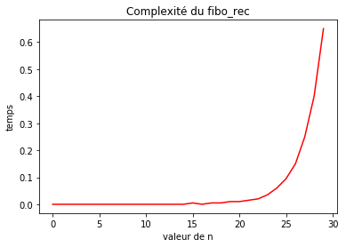

```python
from time import time
L=[]
for n in range(0,30):
    d=time()
    fibo_rec(n)
    f=time()
    L.append(f-d)

import matplotlib.pyplot as plt
plt.plot(range(0,30),L,'r')
plt.title("Complexité du fibo_rec")
plt.xlabel("valeur de n")
plt.ylabel("temps")
plt.show()
```

```python
def fibo_iter(n):
    x,y=1,1
    for i in range(2,n+1):
        w=y+x
        x=y
        y=w
    return y
```

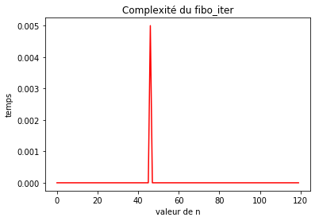

```python
from time import time
L=[]
for n in range(0,120):
    d=time()
    fibo_iter(n)
    f=time()
    L.append(f-d)

import matplotlib.pyplot as plt
plt.plot(range(0,120),L,'r')
plt.title("Complexité du fibo_iter")
plt.xlabel("valeur de n")
plt.ylabel("temps")
plt.show()
```

```python
def fibo(n):
    L=[1]*(n+1)
    for i in range(2,n+1):
        L[i]=L[i-1]+L[i-2]
    return L
```

```python
fibo(5)
```

```
[1, 1, 2, 3, 5, 8]
```

**Exercice 6: Recherche dichotomique**

Soit $L$ une liste triées: On cherche à vérifier si un élément $x$ appartient à $L$ ou non. Pour cela on compare l'élément $x$ avec la valeur de la case au milieu du $L$; si les valeurs sont égales, la tâche est accomplie, sinon on recommence dans la moitié de la liste pertinente.

**Exemple** : pour $x=4$ et L=[1,3,4,6,7,8,10,13,14]

[figure not shown]

Écrire une fonction **rech_dico(L,x)** qui effectue une recherche dichotomique de $x$ dans $L$ et retourne True si $x \in L$.

```python
def rech_dico(L,x):
    L.sort()
    while(L!=[]):
        n=len(L)//2
        if L[n]==x:
            return True
        elif L[n]>x:
            L=L[:n]
        else:
            L=L[n+1:] # on a sauter la case d'indice n car elle ne contient pas x d'après la première condition
    return False
```

```python
def rech_dico_rec(L,x):
    n=len(L)
    L.sort()
    if L==[]:
        return False
    elif x<L[n//2]:
        return rech_dico_rec(L[:n//2],x)
    elif x>L[n//2]:
        return rech_dico_rec(L[n//2+1:],x)
    else:
        return True
```

```python
T=[14,8,3,4,6,10,1,13,7]
print(rech_dico(T,4),rech_dico_rec(T,4))
```

```
True True
```

```python
print(rech_dico(T,44),rech_dico_rec(T,44))
```

```
False False
```

**Exercice 6: (Chiffrement de Cesar)**

1. Écrire une fonction **Cesar_codage(u,k)** qui prend en argument une chaine de caractères $u$ et un entier $k$ et qui permet de translater tous les caractères de $u$ de $k$-caractères vers la droite.

```python
def Cesar_codage(u,k):
    L=list(u)
    T=[]
    for e in L:
        if 'a'<=e<='z':
            if ord(e)+k>ord('z'):
                d=ord(e)+k-ord('z')-1
                T.append(chr(97+d))
            else:
                T.append(chr(ord(e)+k))
        elif 'A'<=e<='Z':
            if ord(e)+k>ord('Z'):
                d=ord(e)+k-ord('Z')-1
                T.append(chr(65+d))
            else:
                T.append(chr(ord(e)+k))
        else:
            T.append(e)
    return ''.join(T)
```

```python
Cesar_codage("Krusty",5)
```

```
'Pwzxyd'
```

```python
Cesar_codage("DUT IDSD1 EST Essaouira 2020",5)
```

```
'IZY NIXI1 JXY Jxxftznwf 2020'
```

```python
#Ici une autre version de la fonction codage_cesare en utilisant des listes contenant les lettres de l'alphabets
```

```python
def Cesar_codage1(u,k):
    A=[chr(65+i) for i in range(26)]
    a=[chr(97+i) for i in range(26)]
    L=list(u)
    T=[]
    for e in L:
        if 'a'<=e<='z':
            T.append(a[(ord(e)-ord('a')+k)%26])
        elif 'A'<=e<='Z':
            T.append(A[(ord(e)-ord('A')+k)%26])
        else:
            T.append(e)
    return ''.join(T)
```

```python
Cesar_codage1("Krusty",5)
```

```
'Pwzxyd'
```

```python
Cesar_codage1("DUT IDSD1 EST Essaouira 2020",5)
```

```
'IZY NIXI1 JXY Jxxftznwf 2020'
```

1. Écrire une fonction **Cesar_decodage(u,k)** qui prend en argument une chaine de caractères $u$ et un entier $k$ et qui permet de translater tous les caractères de $u$ de $k$-caractères vers la gauche.

```python
def Cesar_decodage(u,k):
    L=list(u)
    T=[]
    for e in L:
        if 'a'<=e<='z':
            if ord(e)-k<ord('a'):
                d=ord('a')-ord(e)+k-1
                T.append(chr(ord('z')-d))
            else:
                T.append(chr(ord(e)-k))
        elif 'A'<=e<='Z':
            if ord(e)-k<ord('A'):
                d=ord('A')-ord(e)+k-1
                T.append(chr(ord('Z')-d))
            else:
                T.append(chr(ord(e)-k))
        else:
            T.append(e)
    return ''.join(T)
```

```python
Cesar_decodage('Xfqfr hf Af!! Udymts ',5)
```

```
'Salam ca Va!! Python '
```

```python
def Cesar_decodage1(u,k):
    A=[chr(65+i) for i in range(26)]
    a=[chr(97+i) for i in range(26)]
    L=list(u)
    T=[]
    for e in L:
        if 'a'<=e<='z':
            T.append(a[(ord(e)-ord('a')-k)%26])
        elif 'A'<=e<='Z':
            T.append(A[(ord(e)-ord('A')-k)%26])
        else:
            T.append(e)
    return ''.join(T)
```

```python
Cesar_decodage1('Xfqfr hf Af!! Udymts ',5)
```

```
'Salam ca Va!! Python '
```